# F1 results

Christoffer Trier Månsson

23 mar 2023

# 1 Bets

[figure not shown]

## 1.1 Seneste bets

Det her var buddene inden seneste løb

```
#>          Bets Christoffer       Emil     Mikkel
#> 1      Vinder       Pérez Verstappen      Pérez
#> 2  Andenplads      Alonso      Pérez Verstappen
#> 3 Tredjeplads     Russell     Alonso     Alonso
#> 4       Joker  Verstappen Verstappen Verstappen
```

## 1.2 Seneste top 10

Her præsenterer jeg seneste løbs top 10.

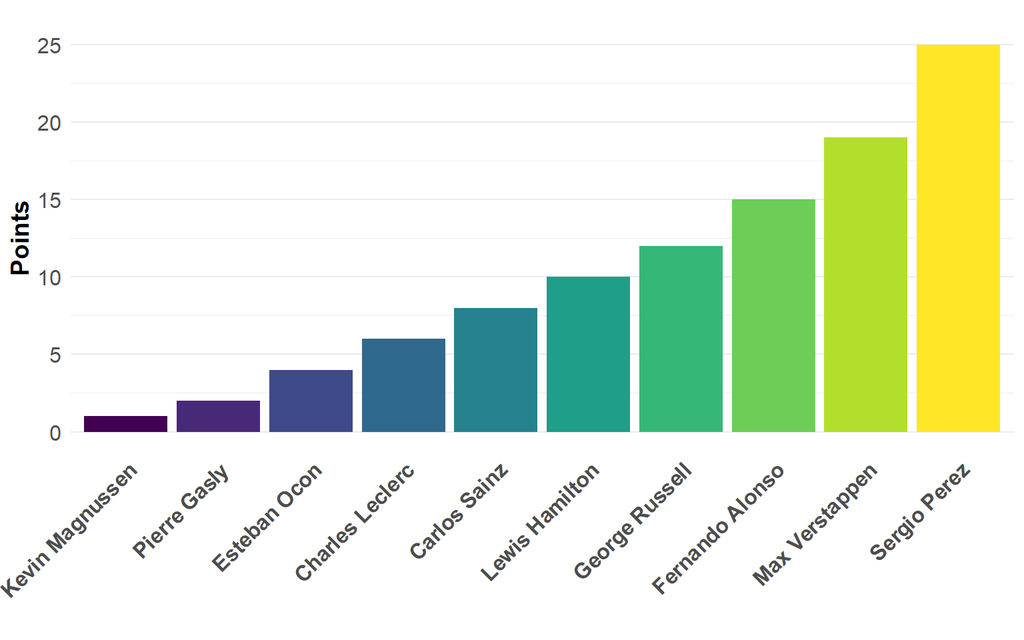

## 1.3 Seneste bet resultat

Her kan man se hvor mange point vi fik efter seneste grandprix.

```
#> [1] "Saudi Arabia"
#>          Bets Christoffer       Emil     Mikkel
#> 1      Vinder       Pérez Verstappen      Pérez
#> 2  Andenplads      Alonso      Pérez Verstappen
#> 3 Tredjeplads     Russell     Alonso     Alonso
#> 4       Joker  Verstappen Verstappen Verstappen
#> 5       Point         -11        -11        -28
```

## 1.4 Seneste Joker resultat

Her kan man se hvordan jokeren har spillet ind på resultatet

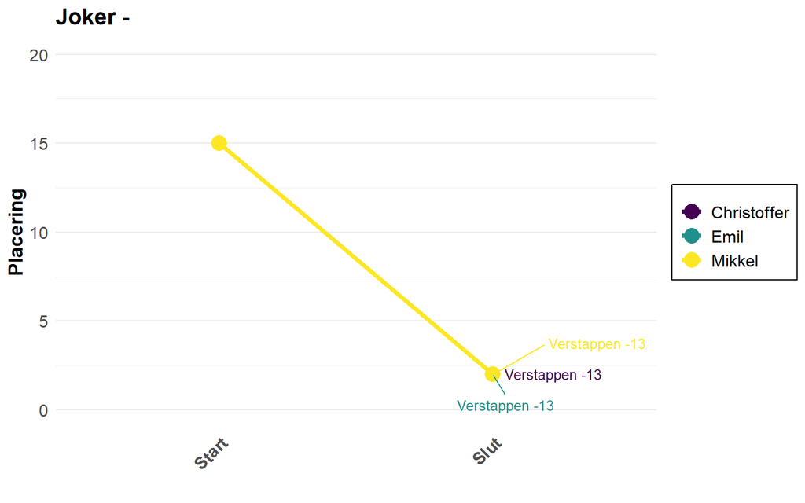

## 1.5 Løbende udvikling for bets

Her kan man se hvordan det går i vores interne konkurrence efter hvert grandprix. Først efter 4. løb vil jeg tage de værste 3 løb ud fra vores totale antal point.

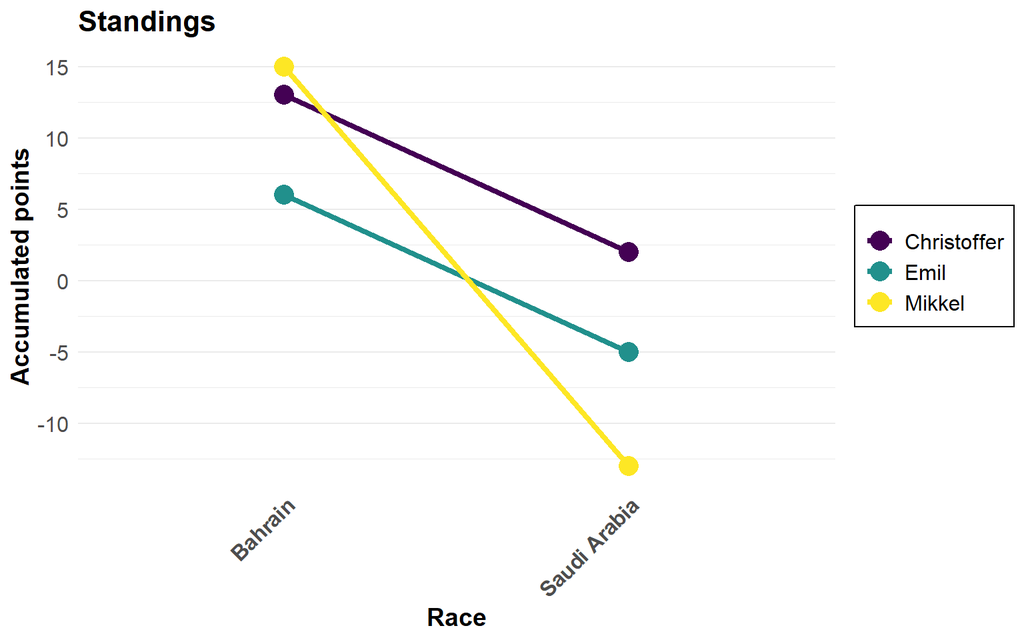

# 2 Kørernes resultater

## 2.1 Kørernes udvikling

Her kan man se hvem der fører løbet og hvordan de har fået point gennem sæsonen Jeg viser top10 + Magnussen

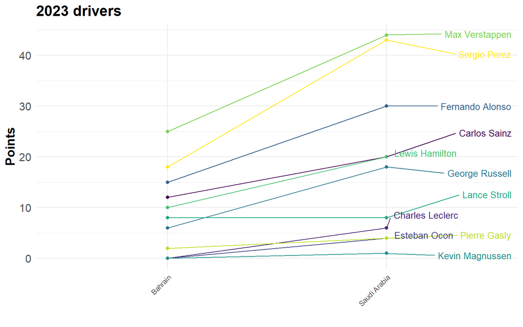

## 2.2 Teamets udvikling

Her kan man se hvordan de enkelte teams scorer point samlet. Her forventer vi jo en klar sejr til Haas ;)

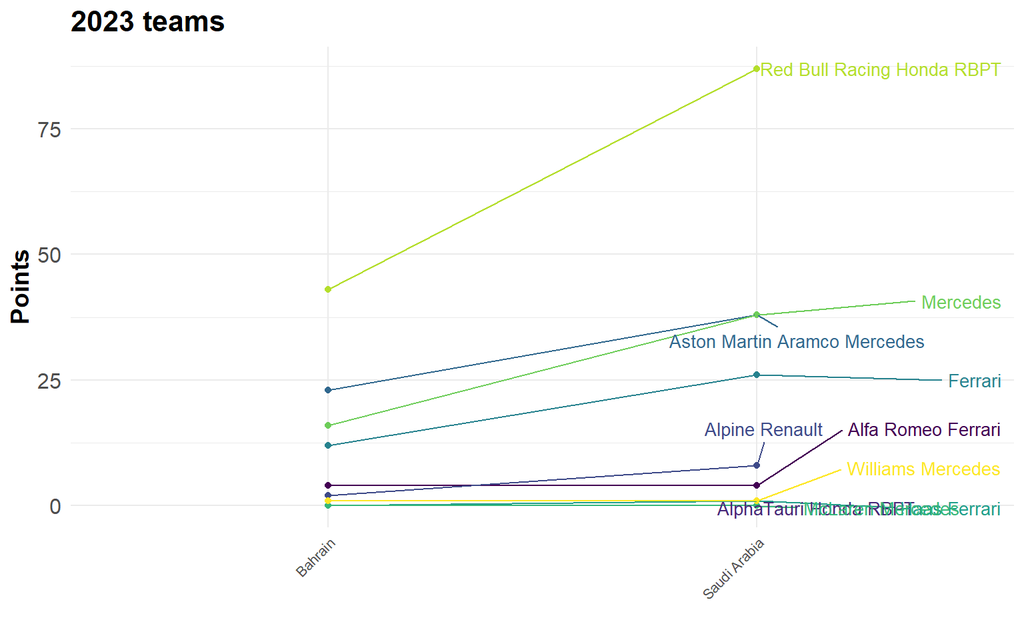

## 2.3 Fold difference from teammate

Det her plot viser hvor mange point den førerne kører fra hvert team har scoret i forhold til hans holdkammerat. Størrelsen og farven på cirklen indikerer hvem mange på point køren har fået. På Y-aksen kan man se hvor mange point han har fået i forhold til sin holdkammerat. Navnet på hans hold og teammate kan ses på X-aksen.

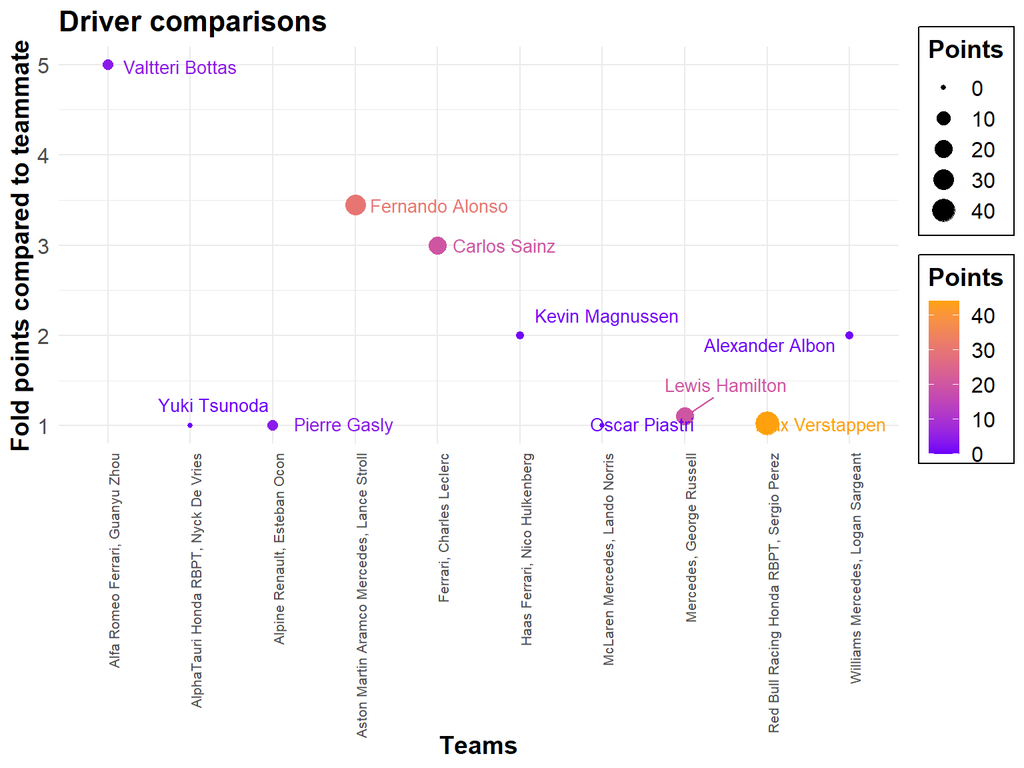

# 3 Regler for spillet

Reglerne er simple. Efter kvallen, men inden løbsdagen skal man have sendt til Christoffer i chatgruppen, **Formula1**, hvilke 3 kører man forventer bliver nummer 1, 2 og 3 i det kommende løb.

**Alle hjælper alle med at huske at der skal indsendes bud på det kommende løb!**

Glemmer man at give noget bud får man 50 point i straf.

Efter hvert løb bliver det beregnet hvor mange pladser ens kører er væk fra den plads man gættede på, at køren blev. Hvis en kører udgår anses det at han slutter sidst og får position 20. Altså kan man minimalt få 0 point (før bonuser og joker), mens man maximalt kan få 54 point (20-1 + 20-2 + 20-3 = 19+18+17 = 54).

Slutter ens kører bedre end man har budt får man stadig plus point

I formel1 sæsonen køres 23 løb. For at give lidt sikkerhed medregnes ens 3 dårligste bud ikke i regnskabet og derfor er hver spillers score baseret på i alt 20 løb til slut i sæsonen.

## 3.1 Bonus

Der udlådes bonus på to måder.

1. Er man den eneste der har løbets vinder gives -5 point
2. Er man den eneste der har løbets top 3 gives -15 point

Har man kun eks. løbets nummer 1 og 2 gives -5 point.

Har man kun løbets nummer 2 og 3 gives ingen bonus.

## 3.2 Joker

Hver uge giver man også et bud på en joker. Det er den kører man forventer vil køre flest placeringer frem i forhold til startpositionen. De placeringer ens joker kører frem trækkes fra ens point. For eksempel vælger man en joker der starter som nummer 17 og der slutter som nummer 10 får man -7 joker point Altså scorer man 10 point på ens top 3 og ens joker går fra 17 til 10 slutter man på 3 point (10 - 7 = 3).

Ender ens joker dårligere end han startede lægger man differencen oven i pointene fra top 3. Altså havde han sluttet som nummer 20 (eller udgået) fra forrige eksempel havde man fået 3 point oveni og ville altså ende på 13 point.

## 3.3 Præmie

Det er blevet besluttet at vi alle skal en tur ud at køre gokart når sæsonen er slut. Her skal nummer 2 og 3 i bettingspillet betale udgifter for nummer 1. **Plus ham der slutter sidst giver en øl i fredagsbaren! ;)**

# 4 Resultaterne for 2022 sæsonen

Her finder man et lille overblik over hvordan 2022 sæsonen gik.

## 4.1 Slut resultat

Sidste års klare vinder var Max Verstappen, men det var meget tæt mellem nummer 2 og 3.

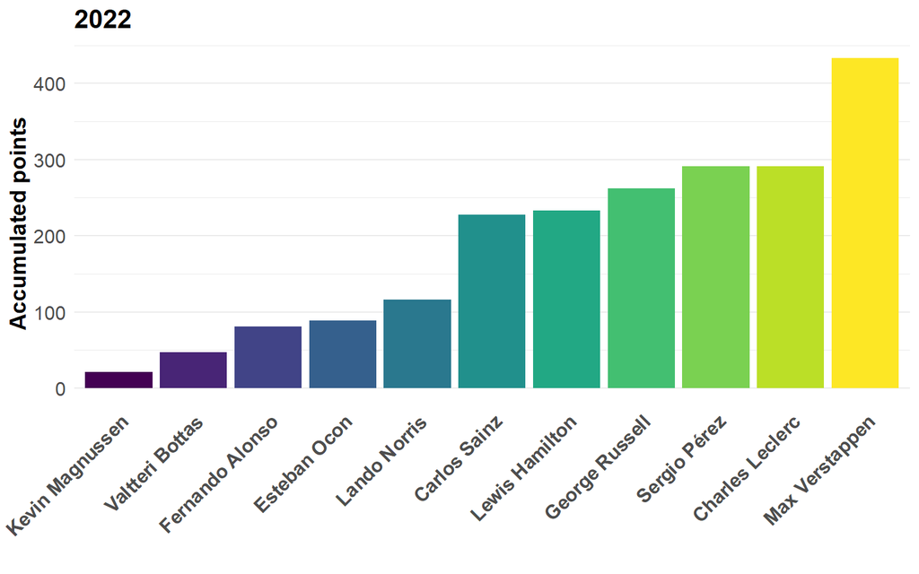

## 4.2 Udviklingen gennem 2022

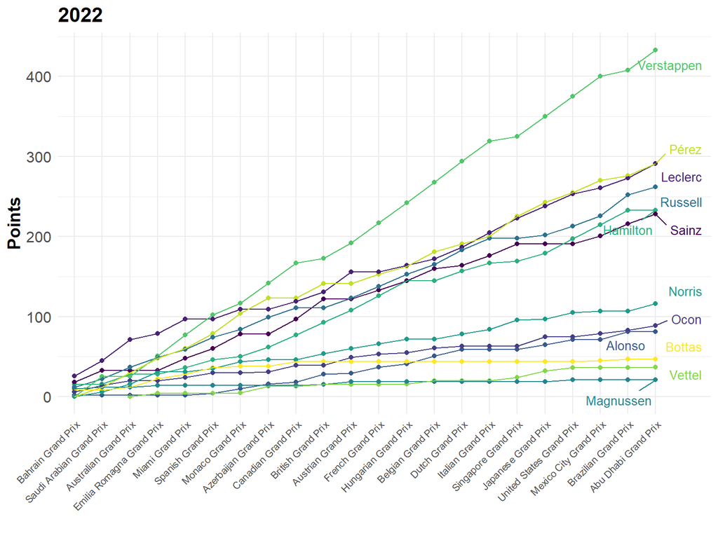

## 4.3 Team ranking i 2022

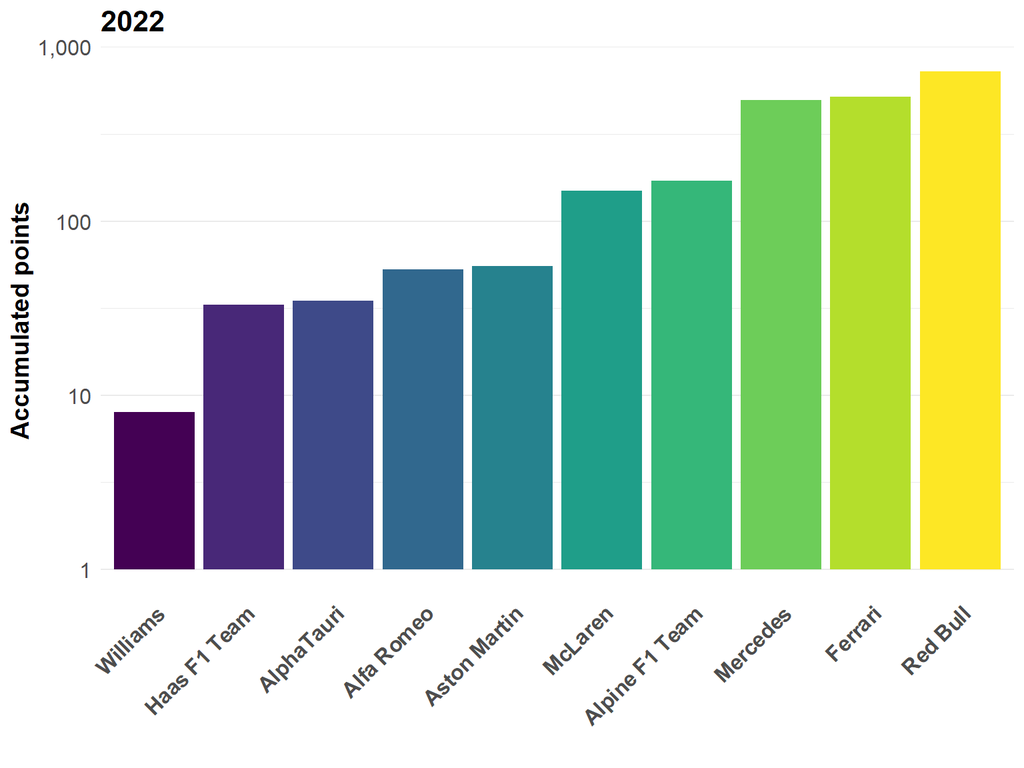

# 5 Information om data

Data er taget fra følgende side https://www.kaggle.com/datasets/rohanrao/formula-1-world-championship-1950-2020?resource=download samt https://github.com/toUpperCase78/formula1-datasets som løbende opdaterer den seneste data fra hele F1

Koden til dette dokument er frit tilgængelig gennem https://github.com/CTrierMaansson/formula1 hvor der også vil komme løbende opdateringer. Jeg henviser til **issues** fanen for bugs og andre problemer man kan have med dokumentet. Her kan man også rette forslag til statistik man ønsker skal være en del af dokumentet.